# GAMs 101

##### Dataset

This notebook aims at presenting basics of Generalized Additive Models (Hastie & Tibsharani, 1996). We are agoing to focus on fictitious (though probable) data of a subscription business where people sign up for receiving meal boxes.

```r
library.list <- c('mgcv', 'forecast', 'openxlsx', 'ggplot2', 'e1071', 'dplyr', 'tidyr')
lapply(library.list, require, character.only=T)
```

```r
set.seed = 2018
setwd('~/Documents/MyHF/GAM_tutorial/')
df <- read.xlsx('subscription_demand.xlsx')
df$year.num <- c(rep(1, 52), rep(2, nrow(df)-52))
df$year <- as.factor(paste0('Year', df$year.num))
head(df)
```

```
  week_number sales holiday.effect planned_churn planned_pauses planned_sales     trend
1          W1  4826              0           209           2401         13302 0.2903136
2          W2  4009              0           298           1703         11203 0.2831192
3          W3  4912              0           439           2630         13680 0.3130158
4          W4  5499              0           485           2829          8075 0.3286836
5          W5  6424              0           584           2791          8695 0.3444313
6          W6  6313              0           578           3005         11392 0.3653350
  year.num  year
1        1 Year1
2        1 Year1
3        1 Year1
4        1 Year1
5        1 Year1
6        1 Year1
```

```r
summary(df)
```

```
 week_number            sales       holiday.effect      planned_churn    planned_pauses
 Length:95          Min.   : 4009   Min.   :-0.009503   Min.   : 166.0   Min.   :1703
 Class :character   1st Qu.: 7506   1st Qu.: 0.000000   1st Qu.: 513.5   1st Qu.:3483
 Mode  :character   Median : 9964   Median : 0.000000   Median : 712.0   Median :5346
                    Mean   : 9830   Mean   : 0.065487   Mean   : 804.4   Mean   :5120
                    3rd Qu.:12139   3rd Qu.: 0.034306   3rd Qu.:1119.5   3rd Qu.:6332
                    Max.   :14204   Max.   : 1.000000   Max.   :1822.0   Max.   :9835
 planned_sales       trend           year.num        year
 Min.   : 8075   Min.   :0.2831   Min.   :1.000   Year1:52
 1st Qu.:18105   1st Qu.:0.5192   1st Qu.:1.000   Year2:43
 Median :23697   Median :0.6502   Median :1.000
 Mean   :22614   Mean   :0.6539   Mean   :1.453
 3rd Qu.:27618   3rd Qu.:0.8033   3rd Qu.:2.000
 Max.   :38554   Max.   :1.0000   Max.   :2.000
```

Our dataset consists of **5 predictors** and a target (‘sales’) in form of number of boxes to be shipped each week. Our ‘planned’ predictors are measured 4 weeks in advance, simply as number of people who plan to churn, pause their subscription or receive a box as usual. Additionally, we will be looking at: - **holiday effect**: note this is a continuous and normalized variable, aggregting effects of seasonality and one-time events - **trend**: a variable denoting ‘baseline’ trend of sales, computed on all data available until t-1 for moment t0; also normalized

Interestingly, **no clear time-related effects** can easily be spotted within our target which suggests that forecasting based on traditional time-series methods (like ARIMAx) might not prove to be the best option.

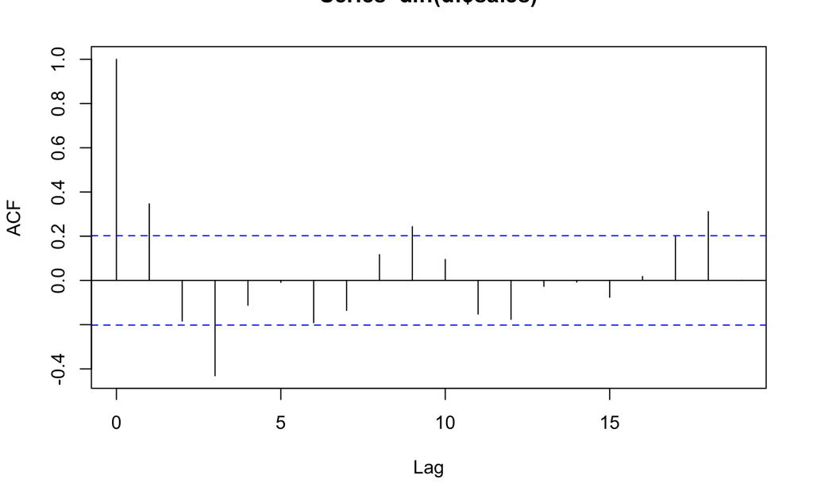

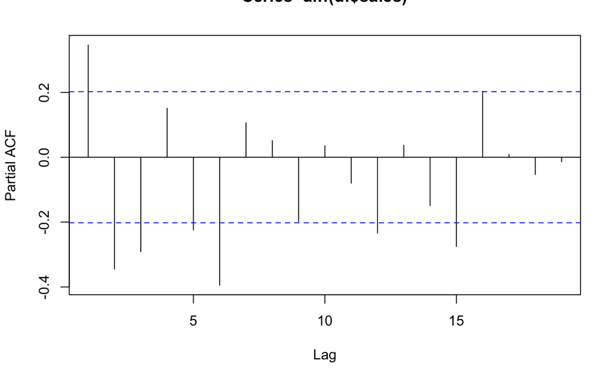

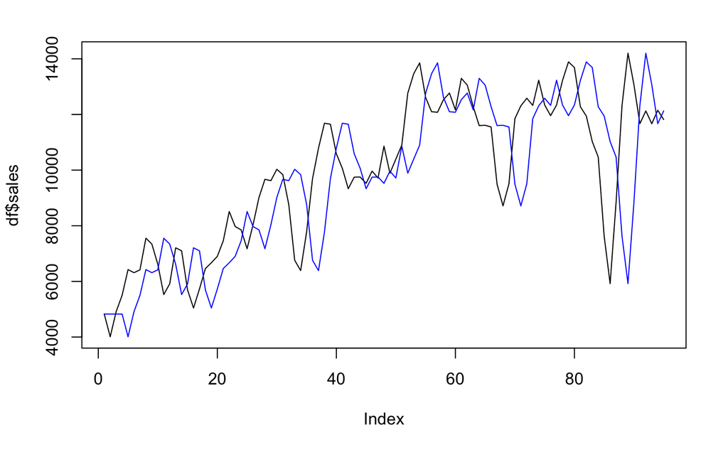

##### Basic GAM

Let’s start with a simple split into train & test. On train set we’ll build a basic GAM, letting the package choose number of knots and going with default smooth settings (‘tp’ - thin plate splines).

`r`r df.train <- df[1:87,] demand.gam.model <- gam(sales ~ s(holiday.effect) + s(planned_sales) + s(planned_pauses) + s(planned_churn) + + s(trend), data = df.train, control=gam.control(mgcv.tol=1e-4)) summary(demand.gam.model)

```
Family: gaussian
Link function: identity

Formula:
sales ~ s(holiday.effect) + s(planned_sales) + s(planned_pauses) +
    s(planned_churn) + +s(trend)

Parametric coefficients:
            Estimate Std. Error t value            Pr(>|t|)
(Intercept)   9595.9      120.8   79.46 <0.0000000000000002 ***
---
Signif. codes:  0 ‘***’ 0.001 ‘**’ 0.01 ‘*’ 0.05 ‘.’ 0.1 ‘ ’ 1

Approximate significance of smooth terms:
                    edf Ref.df      F     p-value
s(holiday.effect) 4.222  4.923 11.615 0.000000012 ***
s(planned_sales)  1.000  1.000  0.810       0.371
s(planned_pauses) 1.881  2.355  0.952       0.351
s(planned_churn)  1.000  1.000  0.837       0.363
s(trend)          2.512  3.128 12.128 0.000000861 ***
---
Signif. codes:  0 ‘***’ 0.001 ‘**’ 0.01 ‘*’ 0.05 ‘.’ 0.1 ‘ ’ 1

R-sq.(adj) =  0.818   Deviance explained =   84%
GCV = 1.4641e+06  Scale est. = 1.2687e+06  n = 87
```

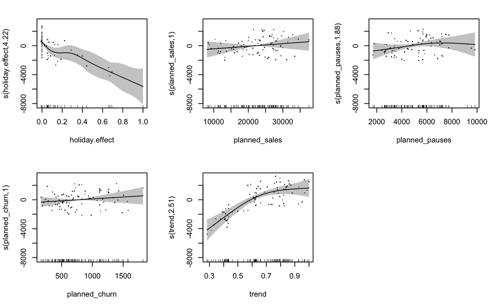

##### Smooths & regularization

A large set of smooth options is available. Most common include: - thin plate splines (‘tp’) - B-splines (‘bs’) - a subset of B-splines: cubic regression splines (‘cr’ or shrunk version, ‘cs’)

See what happens if we switch to cubic splines:

`r`r demand.gam.model <- gam(sales ~ s(holiday.effect, bs=‘cr’) + s(planned_sales, bs=‘cr’) + s(planned_pauses, bs=‘cr’) + s(planned_churn, bs=‘cr’) + + s(trend, bs=‘cr’), data = df.train, control=gam.control(mgcv.tol=1e-4)) summary(demand.gam.model)

```
Family: gaussian
Link function: identity

Formula:
sales ~ s(holiday.effect, bs = \cr\) + s(planned_sales, bs = \cr\) +
    s(planned_pauses, bs = \cr\) + s(planned_churn, bs = \cr\) +
    +s(trend, bs = \cr\)

Parametric coefficients:
            Estimate Std. Error t value Pr(>|t|)
(Intercept)   9595.9      120.5   79.67   <2e-16 ***
---
Signif. codes:  0 ‘***’ 0.001 ‘**’ 0.01 ‘*’ 0.05 ‘.’ 0.1 ‘ ’ 1

Approximate significance of smooth terms:
                    edf Ref.df      F  p-value
s(holiday.effect) 4.249  4.841 11.698 1.88e-08 ***
s(planned_sales)  1.000  1.000  0.811    0.371
s(planned_pauses) 2.127  2.671  1.001    0.331
s(planned_churn)  1.000  1.000  0.828    0.366
s(trend)          2.514  3.121 11.772 1.34e-06 ***
---
Signif. codes:  0 ‘***’ 0.001 ‘**’ 0.01 ‘*’ 0.05 ‘.’ 0.1 ‘ ’ 1

R-sq.(adj) =  0.819   Deviance explained = 84.2%
GCV = 1.462e+06  Scale est. = 1.2622e+06  n = 87
```

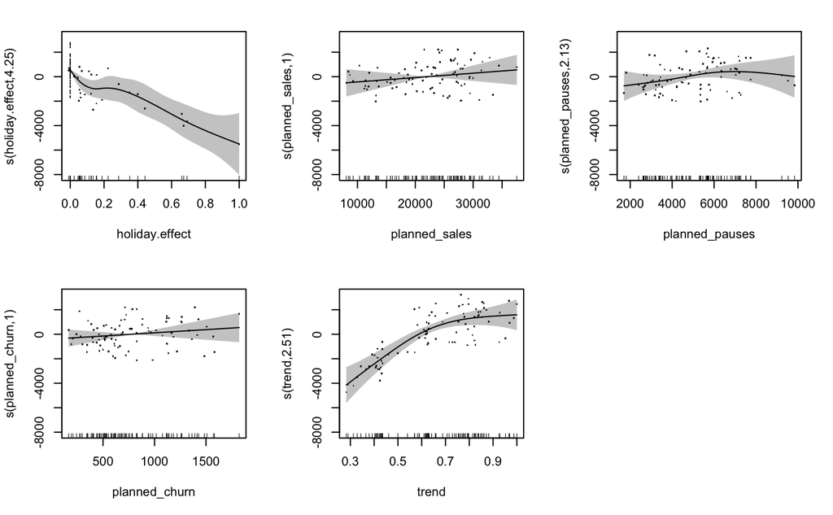

We can use regularization, either via a penalty applied to all terms with select=T or using a shrinkage version of smooths.

`r`r demand.gam.model <- gam(sales ~ s(holiday.effect, bs=‘cr’) + s(planned_sales, bs=‘cr’) + s(planned_pauses, bs=‘cr’) + s(planned_churn, bs=‘cr’) + + s(trend, bs=‘cr’), data = df.train, control=gam.control(mgcv.tol=1e-4), select=T) summary(demand.gam.model)

```
Family: gaussian
Link function: identity

Formula:
sales ~ s(holiday.effect, bs = \cr\) + s(planned_sales, bs = \cr\) +
    s(planned_pauses, bs = \cr\) + s(planned_churn, bs = \cr\) +
    +s(trend, bs = \cr\)

Parametric coefficients:
            Estimate Std. Error t value Pr(>|t|)
(Intercept)   9595.9      118.7   80.85   <2e-16 ***
---
Signif. codes:  0 ‘***’ 0.001 ‘**’ 0.01 ‘*’ 0.05 ‘.’ 0.1 ‘ ’ 1

Approximate significance of smooth terms:
                     edf Ref.df     F  p-value
s(holiday.effect) 4.0899      9 6.946 2.82e-11 ***
s(planned_sales)  0.1611      9 0.092  0.01473 *
s(planned_pauses) 1.8603      9 0.835  0.00528 **
s(planned_churn)  0.4541      7 0.255  0.03590 *
s(trend)          2.4787      9 9.005  < 2e-16 ***
---
Signif. codes:  0 ‘***’ 0.001 ‘**’ 0.01 ‘*’ 0.05 ‘.’ 0.1 ‘ ’ 1

R-sq.(adj) =  0.824   Deviance explained = 84.2%
GCV = 1.3856e+06  Scale est. = 1.2256e+06  n = 87
```

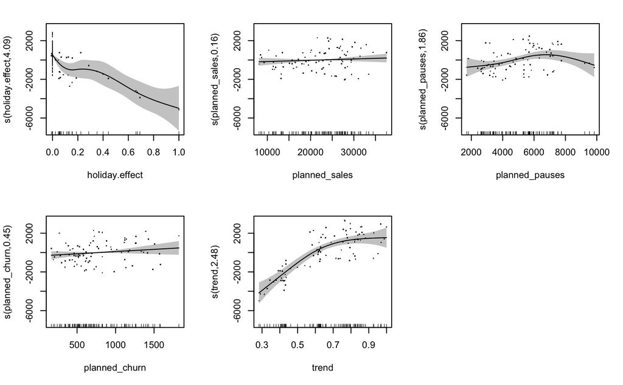

`r`r spline.type <- ‘cs’ demand.gam.model <- gam(sales ~ s(holiday.effect, bs=spline.type) + s(planned_sales, bs=spline.type) + s(planned_pauses, bs=spline.type) + s(planned_churn, bs=spline.type) + + s(trend, bs=spline.type), data = df.train, control=gam.control(mgcv.tol=1e-4)) summary(demand.gam.model)

```
Family: gaussian
Link function: identity

Formula:
sales ~ s(holiday.effect, bs = spline.type) + s(planned_sales,
    bs = spline.type) + s(planned_pauses, bs = spline.type) +
    s(planned_churn, bs = spline.type) + +s(trend, bs = spline.type)

Parametric coefficients:
            Estimate Std. Error t value Pr(>|t|)
(Intercept)   9595.9      119.4   80.39   <2e-16 ***
---
Signif. codes:  0 ‘***’ 0.001 ‘**’ 0.01 ‘*’ 0.05 ‘.’ 0.1 ‘ ’ 1

Approximate significance of smooth terms:
                        edf Ref.df     F  p-value
s(holiday.effect) 4.292e+00      9 6.904 7.71e-11 ***
s(planned_sales)  2.245e-07      9 0.000   0.2757
s(planned_pauses) 2.745e+00      9 0.792   0.0381 *
s(planned_churn)  6.652e-02      9 0.008   0.2865
s(trend)          2.549e+00      9 9.044 3.37e-16 ***
---
Signif. codes:  0 ‘***’ 0.001 ‘**’ 0.01 ‘*’ 0.05 ‘.’ 0.1 ‘ ’ 1

R-sq.(adj) =  0.822   Deviance explained = 84.2%
GCV = 1.4127e+06  Scale est. = 1.2397e+06  n = 87
```

If nature of our relation between predictors and target changes over time, we can introduce a ‘by’ variable.

`r`r spline.type <- ‘cs’ demand.gam.model <- gam(sales ~ year + s(holiday.effect, bs=spline.type, by=year) + s(planned_sales, bs=spline.type) + s(planned_pauses, bs=spline.type) + s(planned_churn, bs=spline.type) + + s(trend, bs=spline.type, by=year), data = df.train, control=gam.control(mgcv.tol=1e-4)) summary(demand.gam.model)

```
Family: gaussian
Link function: identity

Formula:
sales ~ year + s(holiday.effect, bs = spline.type, by = year) +
    s(planned_sales, bs = spline.type) + s(planned_pauses, bs = spline.type) +
    s(planned_churn, bs = spline.type) + +s(trend, bs = spline.type,
    by = year)

Parametric coefficients:
            Estimate Std. Error t value            Pr(>|t|)
(Intercept)   9601.9      402.3  23.865 <0.0000000000000002 ***
yearYear2     3976.3     2746.3   1.448               0.152
---
Signif. codes:  0 ‘***’ 0.001 ‘**’ 0.01 ‘*’ 0.05 ‘.’ 0.1 ‘ ’ 1

Approximate significance of smooth terms:
                                      edf Ref.df      F              p-value
s(holiday.effect):yearYear1 1.66625042476      9  3.151      0.0000006206941 ***
s(holiday.effect):yearYear2 1.75346234627      9  5.694      0.0000000000135 ***
s(planned_sales)            0.00000001922      9  0.000               0.5059
s(planned_pauses)           0.00486302036      9  0.001               0.2105
s(planned_churn)            5.03161160287      9  1.169               0.0565 .
s(trend):yearYear1          7.99295587960      9 19.925 < 0.0000000000000002 ***
s(trend):yearYear2          3.78664059744      8  0.761               0.1515
---
Signif. codes:  0 ‘***’ 0.001 ‘**’ 0.01 ‘*’ 0.05 ‘.’ 0.1 ‘ ’ 1

Rank: 64/65
R-sq.(adj) =  0.891   Deviance explained = 91.8%
GCV = 1.0148e+06  Scale est. = 7.5552e+05  n = 87
```

We can also restrict number of knots used by the algorithm for specific predictors.

`r`r spline.type <- ‘cs’ demand.gam.model <- gam(sales ~ year + s(holiday.effect, bs=spline.type, by=year) + s(planned_sales, bs=spline.type) + s(planned_pauses, bs=spline.type) + s(planned_churn, bs=spline.type, k = 3) + + s(trend, bs=spline.type), data = df.train, control=gam.control(mgcv.tol=1e-4)) summary(demand.gam.model)

```
Family: gaussian
Link function: identity

Formula:
sales ~ year + s(holiday.effect, bs = spline.type, by = year) +
    s(planned_sales, bs = spline.type) + s(planned_pauses, bs = spline.type) +
    s(planned_churn, bs = spline.type, k = 3) + +s(trend, bs = spline.type)

Parametric coefficients:
            Estimate Std. Error t value             Pr(>|t|)
(Intercept)   8729.5      189.9  45.960 < 0.0000000000000002 ***
yearYear2     2133.1      348.2   6.127         0.0000000415 ***
---
Signif. codes:  0 ‘***’ 0.001 ‘**’ 0.01 ‘*’ 0.05 ‘.’ 0.1 ‘ ’ 1

Approximate significance of smooth terms:
                                       edf Ref.df      F              p-value
s(holiday.effect):yearYear1 3.333381025218      9  3.515   0.0000031437586485 ***
s(holiday.effect):yearYear2 1.914830739417      9  8.503   0.0000000000000015 ***
s(planned_sales)            0.000000043970      9  0.000                0.930
s(planned_pauses)           0.000000002713      9  0.000                0.387
s(planned_churn)            0.000000016869      2  0.000                0.346
s(trend)                    6.906934278094      9 19.259 < 0.0000000000000002 ***
---
Signif. codes:  0 ‘***’ 0.001 ‘**’ 0.01 ‘*’ 0.05 ‘.’ 0.1 ‘ ’ 1

R-sq.(adj) =  0.875   Deviance explained = 89.4%
GCV = 1.0419e+06  Scale est. = 8.7235e+05  n = 87
```

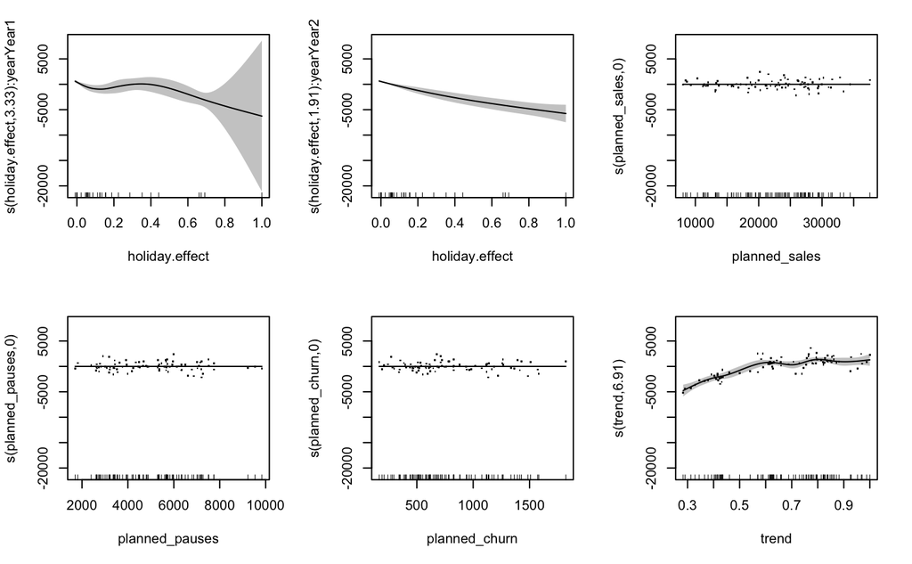

Let’s see if lagged sales could help or not…

`r`r spline.type <- ‘cs’ demand.gam.model <- gam(sales ~ year + s(holiday.effect, bs=spline.type, by=year) + s(planned_sales, bs=spline.type) + s(planned_pauses, bs=spline.type) + s(planned_churn, bs=spline.type) + + s(trend, bs=spline.type) +s(sales_lag3, bs=spline.type), data = df.train, control=gam.control(mgcv.tol=1e-4)) summary(demand.gam.model)

```
Family: gaussian
Link function: identity

Formula:
sales ~ year + s(holiday.effect, bs = spline.type, by = year) +
    s(planned_sales, bs = spline.type) + s(planned_pauses, bs = spline.type) +
    s(planned_churn, bs = spline.type) + +s(trend, bs = spline.type) +
    s(sales_lag3, bs = spline.type)

Parametric coefficients:
            Estimate Std. Error t value             Pr(>|t|)
(Intercept)   8465.7      232.0  36.489 < 0.0000000000000002 ***
yearYear2     2759.8      498.8   5.532          0.000000658 ***
---
Signif. codes:  0 ‘***’ 0.001 ‘**’ 0.01 ‘*’ 0.05 ‘.’ 0.1 ‘ ’ 1

Approximate significance of smooth terms:
                                       edf Ref.df     F         p-value
s(holiday.effect):yearYear1 3.097291823831      9 4.220 0.0000001474930 ***
s(holiday.effect):yearYear2 1.707659791877      9 5.379 0.0000000000112 ***
s(planned_sales)            0.000000054004      9 0.000           0.936
s(planned_pauses)           0.000000005173      9 0.000           0.526
s(planned_churn)            4.385359309658      9 0.816           0.122
s(trend)                    6.541585036454      9 5.963 0.0000000257239 ***
s(sales_lag3)               6.579021265600      9 1.149           0.127
---
Signif. codes:  0 ‘***’ 0.001 ‘**’ 0.01 ‘*’ 0.05 ‘.’ 0.1 ‘ ’ 1

R-sq.(adj) =  0.889   Deviance explained = 91.9%
GCV = 1.0764e+06  Scale est. = 7.7561e+05  n = 87
```

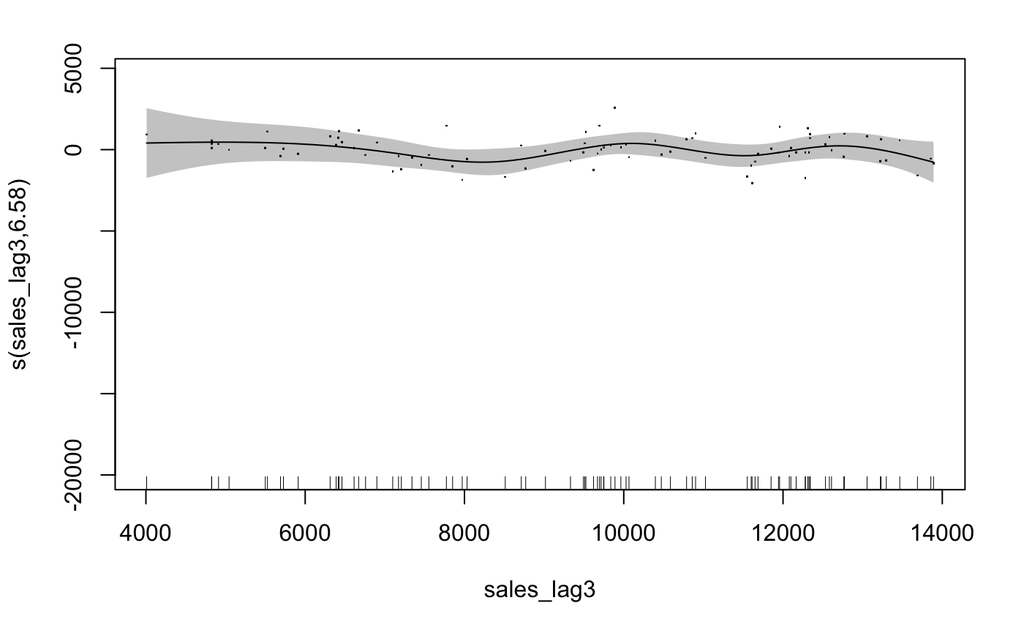

`r`r param.grid <- expand.grid(cost = c(0.001, 0.01, 0.1, 1, 2, 3, 5, 10, 20, 50), gamma = c(0.01, 0.02, 0.05, 0.1, 0.25, 0.5, 1)) all.errors <- data.frame() for (mm in (83:87)) { errors <- data.frame() for (p in 1:nrow(param.grid)) { svr.model <- svm(sales ~ ., data = df[1:mm,2:8], kernel = ‘radial’, cost = param.grid$cost[p], gamma = param.grid$gamma[p]) errors <- rbind(errors, c(param.grid$cost[p], param.grid$gamma[p], mean(abs(df[(mm+1):(mm+8),2] - predict(svr.model, newdata = df[(mm+1):(mm+8),2:8]))))) } names(errors) <- c(‘cost’,‘gamma’,paste0(‘error’, mm)) if (mm==83) { all.errors <- errors } else { all.errors <- inner_join(all.errors, errors, by=c(‘cost’,‘gamma’)) } } all.errors$avg.error <- apply(all.errors[,3:7], 1, mean) all.errors <- all.errors[order(all.errors$avg.error),] all.errors[1:10,]

[figure not shown]

`r`r head(marketing.data)

```
  Conversions  TVSpend  Facebook Affiliate Xmas.flag Weekday SEM.nonbrand SEM.brand     Date
1    129.7402     0.00  966.1242  878.1161         0       4     517499.8  28141.86 1/1/2015
2    254.5247 18924.37 1476.9990 1761.6520         0       5     724479.7  41007.38 1/2/2015
3    174.8172 16640.91 1111.6523 1556.0475         0       6     608372.4  34048.92 1/3/2015
4    272.5388 91810.40 1383.1496 1352.0555         0       0     739891.4  39898.64 1/4/2015
5    250.8259 33142.27 1397.4223 1515.8831         0       1     799787.8  40652.78 1/5/2015
6    219.8641 89730.86 1383.8384 1425.1942         0       2     711212.0  42497.55 1/6/2015
```

##### Marketing attribution

The key question is how to obtain contributions to target (eg conversions) from each channel where we spent money.

`r`r mrktg.gam <- gam(Conversions ~ s(TVSpend, bs = spline.type) + s(Facebook, bs = spline.type) + s(Affiliate, bs = spline.type) + s(SEM.nonbrand, bs = spline.type) + s(SEM.brand, bs = spline.type) + Xmas.flag + s(Weekday, k = 7), data = marketing.data) summary(mrktg.gam)

```
Family: gaussian
Link function: identity

Formula:
Conversions ~ s(TVSpend, bs = spline.type) + s(Facebook, bs = spline.type) +
    s(Affiliate, bs = spline.type) + s(SEM.nonbrand, bs = spline.type) +
    s(SEM.brand, bs = spline.type) + Xmas.flag + s(Weekday, k = 7)

Parametric coefficients:
            Estimate Std. Error t value             Pr(>|t|)
(Intercept)   131.94       1.54  85.659 < 0.0000000000000002 ***
Xmas.flag     -55.55      18.35  -3.028              0.00265 **
---
Signif. codes:  0 ‘***’ 0.001 ‘**’ 0.01 ‘*’ 0.05 ‘.’ 0.1 ‘ ’ 1

Approximate significance of smooth terms:
                  edf Ref.df      F           p-value
s(TVSpend)      5.937      9  3.393 0.000020304362708 ***
s(Facebook)     1.342      9  3.939 0.000000000492655 ***
s(Affiliate)    5.974      9  7.986 0.000000000000172 ***
s(SEM.nonbrand) 5.482      9  3.841 0.000000539634848 ***
s(SEM.brand)    5.753      9  6.499 0.000000000030478 ***
s(Weekday)      1.000      1 46.952 0.000000000030962 ***
---
Signif. codes:  0 ‘***’ 0.001 ‘**’ 0.01 ‘*’ 0.05 ‘.’ 0.1 ‘ ’ 1

R-sq.(adj) =  0.752   Deviance explained =   77%
GCV = 927.51  Scale est. = 857.66    n = 365
```

`r`r df.terms <- predict(mrktg.gam, type=‘terms’) head(df.terms, 20)

```
   Xmas.flag   s(TVSpend) s(Facebook) s(Affiliate) s(SEM.nonbrand) s(SEM.brand)   s(Weekday)
1          0  -6.43499340    3.403904    -2.472496      -0.1806309     8.272442  -6.13910937
2          0   2.70515732   27.432417    17.235237       7.9657413     7.611191 -12.29508442
3          0   1.94541574   10.111518    18.436224      -0.1673834     5.865551 -18.45105947
4          0  -6.36201471   23.009765    21.513430       8.1775042     7.443931  18.48479085
5          0   5.52366617   23.686711    18.848218       4.3526012     7.582798  12.32881579
6          0  -5.76228700   23.042462    20.103784       7.4012600     7.449704   6.17284074
7          0   5.83218406   15.278750    19.866810       7.2876440     7.570666   0.01686568
8          0  -2.69871782   24.922514    24.324427       8.0840592     6.268143  -6.13910937
9          0   1.66701947   20.458522    22.350103       8.0237578     6.769627 -12.29508442
10         0   4.78466341   18.108424     2.678858       7.9890040     5.845893 -18.45105947
11         0  -0.03673737   33.012295    17.183074      -1.1619589     4.473904  18.48479085
12         0   2.49743451   29.513216    24.802099       8.1207093     3.831372  12.32881579
13         0   5.61479144   17.774749    20.713741       3.5811480     5.938152   6.17284074
14         0   4.99899032   21.469558    16.204698      -0.2651983     7.157530   0.01686568
15         0   3.02100178   15.805827    15.616796       0.1019052     4.104200  -6.13910937
16         0   2.58465898   12.656246    16.178270      -0.5474785     4.154407 -12.29508442
17         0  -1.01462101   16.540083    24.905491       1.2627528     6.241531 -18.45105947
18         0 -13.16628292   39.589014    20.707158       0.5037197    32.560914  18.48479085
19         0   2.30538438   34.204468    21.904368      -1.1382357    46.727681  12.32881579
20         0   3.14416213   31.367935    17.935322       4.7838939    16.014864   6.17284074
```

`r`r plot(mrktg.gam, pages = 2, shade=T, residuals = T)

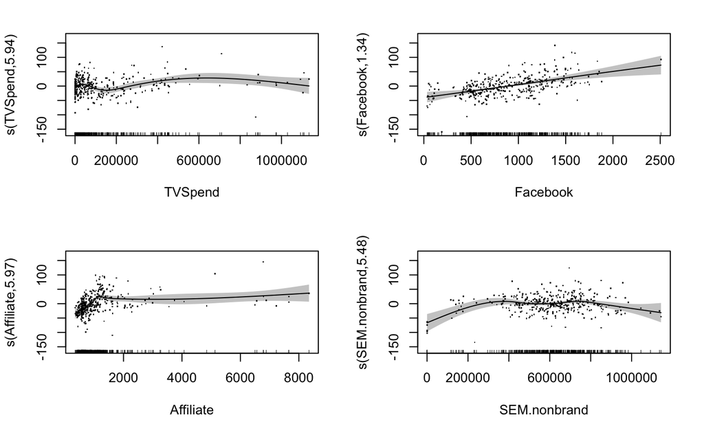

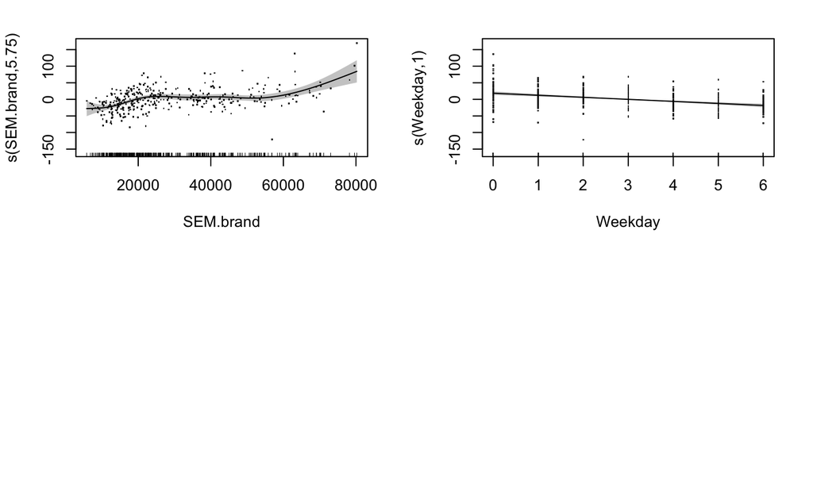

Some models require applying shape constraints so that we get non-negative impact of channels. Then new splines can be used, e.g: - mpi - monotonic increasing penalized B-splines - micv - monotonic convex increasing B-splines etc. Typically shape constraints result in underfitting .

`r`r scam.spline.type = ‘mpi’ #marketing.data$Weekday.factor <- as.factor(marketing.data$Weekday) mrktg.scam <- scam(Conversions ~ s(TVSpend, bs = scam.spline.type) + s(Facebook, bs = scam.spline.type) + s(Affiliate, bs = scam.spline.type) + s(SEM.nonbrand, bs = scam.spline.type) + s(SEM.brand, bs = scam.spline.type) + Xmas.flag + s(Weekday, k=7), data = marketing.data) summary(mrktg.scam)

```
Family: gaussian
Link function: identity

Formula:
Conversions ~ s(TVSpend, bs = scam.spline.type) + s(Facebook,
    bs = scam.spline.type) + s(Affiliate, bs = scam.spline.type) +
    s(SEM.nonbrand, bs = scam.spline.type) + s(SEM.brand, bs = scam.spline.type) +
    Xmas.flag + s(Weekday, k = 7)

Parametric coefficients:
            Estimate Std. Error t value Pr(>|t|)
(Intercept)  -508.18     208.92  -2.432  0.01550 *
Xmas.flag     -56.26      19.21  -2.929  0.00363 **
---
Signif. codes:  0 ‘***’ 0.001 ‘**’ 0.01 ‘*’ 0.05 ‘.’ 0.1 ‘ ’ 1

Approximate significance of smooth terms:
                  edf Ref.df      F              p-value
s(TVSpend)      2.001  2.003  6.284              0.00207 **
s(Facebook)     4.217  4.566 34.609 < 0.0000000000000002 ***
s(Affiliate)    2.389  2.799 18.653     0.00000000020081 ***
s(SEM.nonbrand) 0.000  0.000     NA              1.00000
s(SEM.brand)    4.716  5.033 13.278     0.00000000000529 ***
s(Weekday)      1.003  1.006 33.235     0.00000001654904 ***
---
Signif. codes:  0 ‘***’ 0.001 ‘**’ 0.01 ‘*’ 0.05 ‘.’ 0.1 ‘ ’ 1

R-sq.(adj) =  0.7244   Deviance explained = 73.6%
GCV score = 993.71  Scale est. = 951.23    n = 365

BFGS termination condition:
0.0001012689
```

[figure not shown]

[figure not shown]